# Underlying Exploration

```r
# Load packages
library(tidyverse)
```

```r
library(ggplot2)
library(readxl)
library(lubridate)
library(janitor)
# Global options
knitr::opts_chunk$set(echo = TRUE, warning = FALSE, message = FALSE)

source("../Scripts/functions.R")
```

This document contains the analyses used to replicate Vaca et al. (2011). Datasets are pulled from the `/Cleandata` directory, which were produced in the `/scripts/Cleaning.Rmd` document.

# 1 All-Cause Mortality

We are going to start by importing our all-cause data and plot the rates by year.

```r
all_cause <- read.csv("../CleanData/all_cause_UCD.csv")
head(all_cause)
```

```
##   X year    sex age_group       cod race_eth deaths
## 1 1 1999 female       0-4 all_cause    black    245
## 2 2 1999 female       0-4 all_cause hispanic    703
## 3 3 1999 female       0-4 all_cause    white    446
## 4 4 1999   male       0-4 all_cause    black    266
## 5 5 1999   male       0-4 all_cause hispanic    878
## 6 6 1999   male       0-4 all_cause    white    569
```

```r
#adding pop data
dof_data<- read_csv("../CleanData/dof_data_grouped.csv")

#merging
all_cause <- left_join(all_cause,dof_data,
                                by = c("year", "sex", "race_eth", "age_group"))
head(all_cause)
```

```
##   X year    sex age_group       cod race_eth deaths population
## 1 1 1999 female       0-4 all_cause    black    245   117672.4
## 2 2 1999 female       0-4 all_cause hispanic    703   708958.7
## 3 3 1999 female       0-4 all_cause    white    446   497911.0
## 4 4 1999   male       0-4 all_cause    black    266   121620.5
## 5 5 1999   male       0-4 all_cause hispanic    878   739400.0
## 6 6 1999   male       0-4 all_cause    white    569   526744.7
```

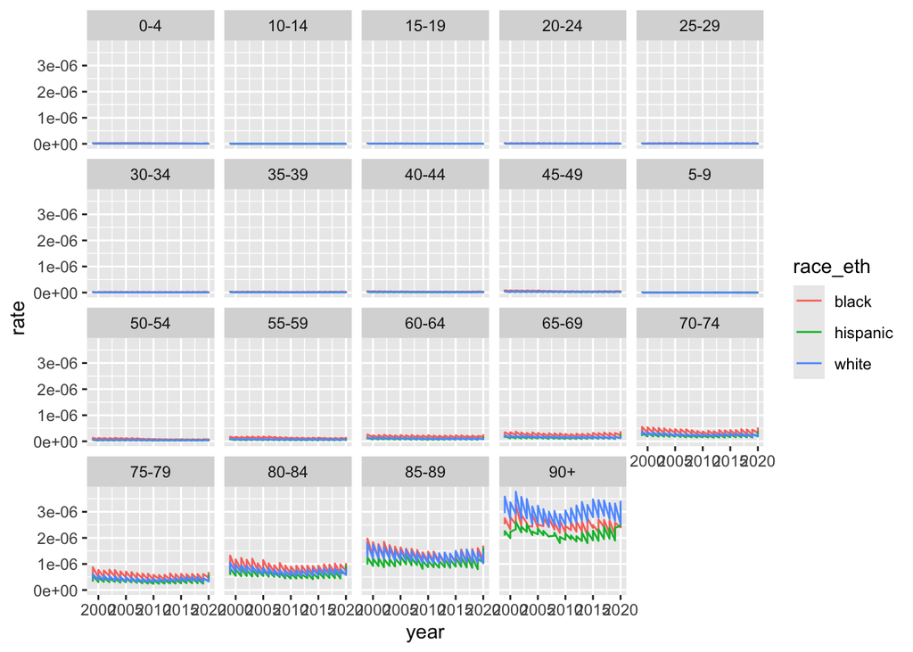

```r
#making a rate per 100k variable

all_cause <- all_cause %>%
  mutate(rate = deaths/(population*100000))

#plotting by year
ggplot(all_cause, aes(year, rate, col= race_eth))+
  facet_wrap(~age_group)+
  geom_line()
```

```r
#table of all ages by year, sex, and race/eth
all_cause %>%
    group_by(race_eth, year, sex) %>%
    summarise(
      deaths = sum(deaths, na.rm=TRUE),
      pop    = sum(population, na.rm=TRUE),
      .groups="drop"
    ) %>%
    mutate(rate = deaths/pop*100000)
```

```
## # A tibble: 132 × 6
##    race_eth  year sex    deaths      pop  rate
##    <chr>    <dbl> <chr>   <int>    <dbl> <dbl>
##  1 black     1999 female   8737 1173834.  744.
##  2 black     1999 male     9135 1128634.  809.
##  3 black     2000 female   8494 1126327   754.
##  4 black     2000 male     9170 1084519   846.
##  5 black     2001 female   8750 1124629.  778.
##  6 black     2001 male     9461 1085475.  872.
##  7 black     2002 female   8911 1128367.  790.
##  8 black     2002 male     9667 1090175.  887.
##  9 black     2003 female   8987 1131191.  794.
## 10 black     2003 male     9720 1094775.  888.
## # ℹ 122 more rows
```

```r
youths <- c("15-19", "20-24")

#table of 15-24 year old males by year
all_cause %>%
  filter(sex == "male",
         age_group %in% youths ) %>%
    group_by(race_eth, year, sex) %>%
    summarise(
      deaths = sum(deaths, na.rm=TRUE),
      pop    = sum(population, na.rm=TRUE),
      .groups="drop"
    ) %>%
    mutate(rate = deaths/pop*100000) %>%
  select(-deaths, -pop)
```

```
## # A tibble: 66 × 4
##    race_eth  year sex    rate
##    <chr>    <dbl> <chr> <dbl>
##  1 black     1999 male   186.
##  2 black     2000 male   229.
##  3 black     2001 male   223.
##  4 black     2002 male   233.
##  5 black     2003 male   231.
##  6 black     2004 male   248.
##  7 black     2005 male   259.
##  8 black     2006 male   234.
##  9 black     2007 male   219.
## 10 black     2008 male   195.
## # ℹ 56 more rows
```

# 2 Descriptive Analysis

## 2.1 Total Death Count

How many deaths occurred over the study period?

```r
all_cause %>%
  filter(year %in% 2007:2020) %>%
  summarize(total_deaths = sum(deaths, na.rm = TRUE))
```

```
##   total_deaths
## 1      3190417
```

## 2.2 Age-adjusted mortality rates

What are the age-adjusted mortality rates for each race/ethnicity group?

```r
#Step 1: keep deaths and population by age group
data_age <- all_cause %>%
  filter(
    year %in% 2007:2020,
    !is.na(age_group)
  ) %>%
  group_by(race_eth, age_group) %>%
  summarise(deaths = sum(deaths, na.rm = TRUE),
            pop = sum(population, na.rm = TRUE),
            .groups="drop")
head(data_age)
```

```
## # A tibble: 6 × 4
##   race_eth age_group deaths      pop
##   <chr>    <chr>      <int>    <dbl>
## 1 black    0-4         4555 2178899.
## 2 black    10-14        426 2036311.
## 3 black    15-19       2068 2306602.
## 4 black    20-24       3743 2378810.
## 5 black    25-29       4053 2318213.
## 6 black    30-34       4426 2159961.
```

```r
# Step 2: Obtain standard population weight
dof_data <- read.csv("../CleanData/dof_data_grouped.csv")
std_pop <- dof_data %>%
  filter(
    year == 2000
  ) %>%
  group_by(age_group) %>%
  summarise(std_pop = sum(population), .groups="drop") %>%
  mutate(weight = std_pop / sum(std_pop))

# Step 3: compute age-specific rates
data_age <- data_age %>%
  mutate(rate = deaths / pop)

# Step 4: join weights + calculate weighted rates
adj_rates <- data_age %>%
  left_join(std_pop, by="age_group") %>%
  mutate(weighted_rate = rate * weight)

#sum weighted rates --> age-adjusted rates
table1_adj <- adj_rates %>%
  group_by(race_eth) %>%
  summarise(
    age_adj_rate = sum(weighted_rate) * 100000,
    .groups="drop"
  )
table1_adj
```

```
## # A tibble: 3 × 2
##   race_eth age_adj_rate
##   <chr>           <dbl>
## 1 black            853.
## 2 hispanic         535.
## 3 white            639.
```

# 3 Table 1

2. create a population weighting variable for 2000 to standardize age-adjustments
3. compute age-specific weights
4. Join weights to calculate age-adjusted rates
5. Calculate 95% CIs using log normal approximation to the Poisson distribution

# 4 All Cause

## 4.1 Fig 1- Male

Male all-cause mortality rate ratios comparing Hispanic and non-Hispanic black mortality to non-Hispanic white mortality, by 5 year age groups with 95% CI, California, 2007-2020.

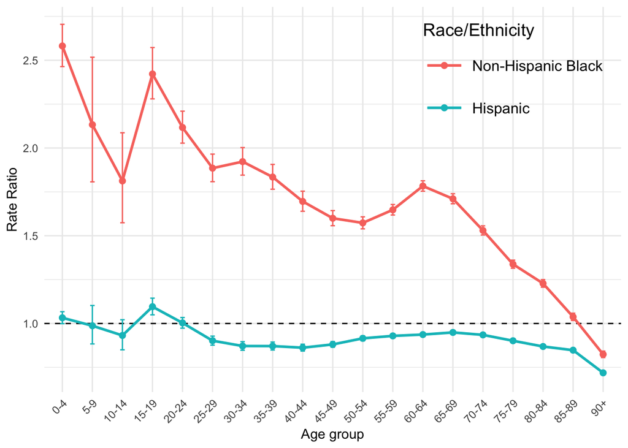

```r
yrs_0720 <- 2007:2020
fig1 <- calc_rates(all_cause,yrs_0720,"male","all_cause") %>%
  calc_rr()

plot_rr(fig1,NULL)
```

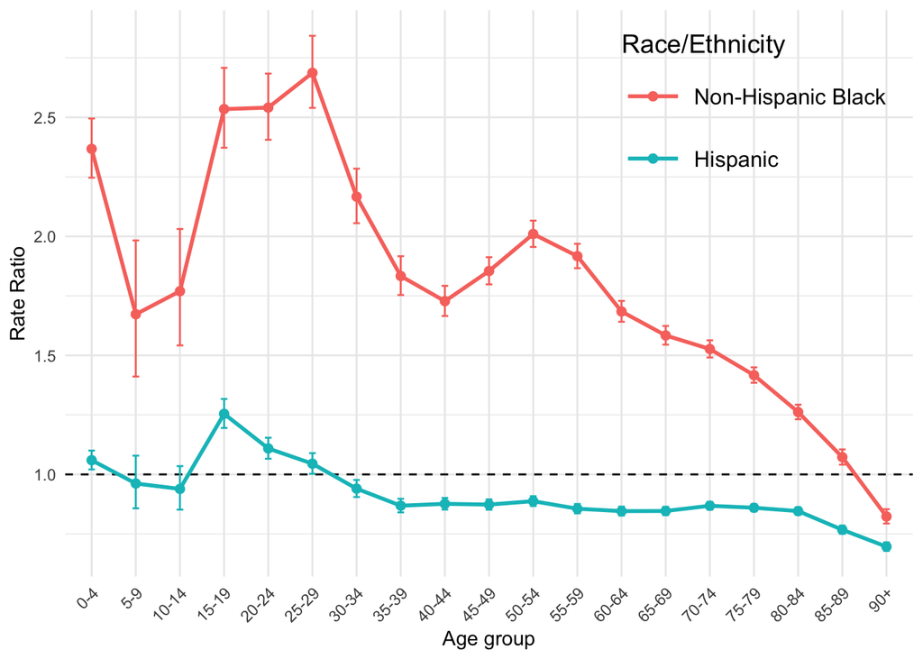

```r
#trying again, this time for the other years
yrs_9906 <-c(1999:2006)
fig1_old <- calc_rates(all_cause,yrs_9906,"male","all_cause") %>%
  calc_rr()

plot_rr(fig1_old,NULL)
```

Looking through the numbers:

```r
tables_by_race <- fig1 %>%
  mutate(rr_ci = sprintf("%.2f (%.2f, %.2f)", rr, rr_lcl, rr_ucl)) %>%
  select(race_eth, age_group, rr_ci) %>%
  arrange(race_eth, age_group) %>%
  group_split(race_eth)

names(tables_by_race) <- unique(fig1$race_eth)

tables_by_race
```

```
## <list_of<
##   tbl_df<
##     race_eth : character
##     age_group: ordered<0b4a0>
##     rr_ci    : character
##   >
## >[2]>
## $black
## # A tibble: 19 × 3
##    race_eth age_group rr_ci
##    <chr>    <ord>     <chr>
##  1 black    0-4       2.58 (2.46, 2.70)
##  2 black    5-9       2.13 (1.81, 2.52)
##  3 black    10-14     1.81 (1.57, 2.09)
##  4 black    15-19     2.42 (2.28, 2.57)
```

[output cut: 39 more lines]

## 4.2 Fig 2- Female

Female all cause mortality rate ratios comparing Hispanic and non-Hispanic black mortality to non-Hispanic white mortality, by 5 year age groups with 95% CI, California, 2007-2020.

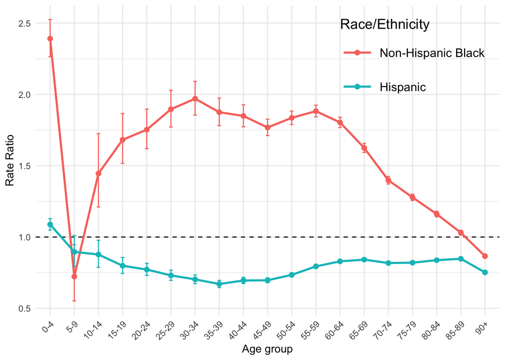

```r
fig2 <- all_cause %>%
  calc_rates(yrs_0720,"female","all_cause") %>%
  calc_rr()

plot_rr(fig2, NULL)
```

```r
fig2_plot <- plot_rr(fig2, NULL)
ggsave(
  filename = "../Output/fig2.png",
  plot = fig2_plot,
  width = 10,
  height = 6
)
```

There is a slight problem here, because we are missing the 5-9 counts for Blacks most of the years due to data suppression. Because of this, we will eventually need to exclude this group.

Looking through the numbers:

```r
tables_by_race <- fig2 %>%
  mutate(rr_ci = sprintf("%.2f (%.2f, %.2f)", rr, rr_lcl, rr_ucl)) %>%
  select(race_eth, age_group, rr_ci) %>%
  arrange(race_eth, age_group) %>%
  group_split(race_eth)

names(tables_by_race) <- unique(fig1$race_eth)

tables_by_race
```

```
## <list_of<
##   tbl_df<
##     race_eth : character
##     age_group: ordered<0b4a0>
##     rr_ci    : character
##   >
## >[2]>
## $black
## # A tibble: 19 × 3
##    race_eth age_group rr_ci
##    <chr>    <ord>     <chr>
##  1 black    0-4       2.39 (2.26, 2.53)
##  2 black    5-9       0.72 (0.55, 0.95)
##  3 black    10-14     1.45 (1.21, 1.73)
##  4 black    15-19     1.68 (1.52, 1.87)
```

[output cut: 39 more lines]

# 5 Homicide

We will pull two cleaned datasets for this, including the homicide counts by age group for the whole study period, and the homicide counts by year.

## 5.1 Fig 3- Male

Male homicide mortality rates, comparing Hispanic, non-Hispanic black, and non-Latino white, 5 year age groups, California 2007-2020.

```r
hom_age <- read.csv("../CleanData/homicide_UCD_age_groups.csv")
head(hom_age)
```

```
##   X race_eth age_group      cod deaths population
## 1 1    black       0-4 homicide     91    1104550
## 2 2    black     10-14 homicide     37    1031841
## 3 3    black     15-19 homicide    867    1177784
## 4 4    black     20-24 homicide   1405    1224919
## 5 5    black     25-29 homicide   1134    1196638
## 6 6    black     30-34 homicide    874    1105255
```

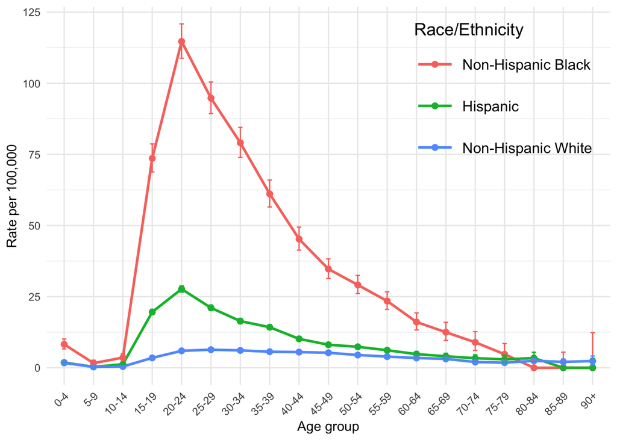

```r
fig3 <- hom_age %>%
    mutate(rate = deaths/population*100000) %>%
    set_age_order() %>%
   rowwise() %>%
  mutate(ci_exact(deaths,population)) %>%
  ungroup()

plot_rate(fig3,NULL)
```

```r
fig3_plot <- plot_rate(fig3, NULL)
ggsave(
  filename = "../Output/fig3UCD.png",
  plot = fig3_plot,
  width = 10,
  height = 6
)
```

By number:

```r
tables_by_race <- fig3 %>%
  mutate(r_ci = sprintf("%.2f (%.2f, %.2f)", rate, lcl, ucl)) %>%
  select(race_eth, age_group, r_ci) %>%
  arrange(race_eth, age_group) %>%
  group_split(race_eth)

names(tables_by_race) <- unique(fig3$race_eth)

tables_by_race
```

```
## <list_of<
##   tbl_df<
##     race_eth : character
##     age_group: ordered<0b4a0>
##     r_ci     : character
##   >
## >[3]>
## $black
## # A tibble: 19 × 3
##    race_eth age_group r_ci
##    <chr>    <ord>     <chr>
##  1 black    0-4       8.24 (6.63, 10.12)
##  2 black    5-9       1.62 (0.91, 2.68)
##  3 black    10-14     3.59 (2.52, 4.94)
##  4 black    15-19     73.61 (68.79, 78.68)
```

[output cut: 63 more lines]

## 5.2 Figure 5: Male 15-24

Homicide mortality rates, among males 15-24 years of age, comparing Hispanic, non-Hispanic black, and non-Hispanic white, by year with 95% CI, California 2007-2020.

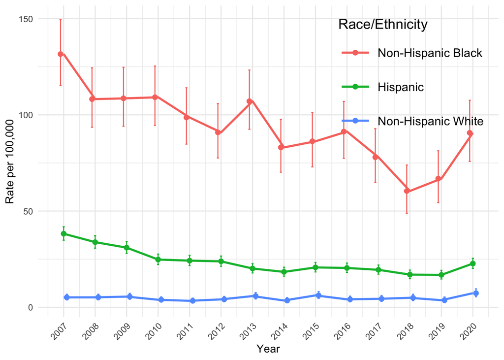

```r
fig5data <- read.csv("../CleanData/homicide_UCD_yearly.csv")
fig5 <- fig5data %>%
  mutate(rate=deaths/population*100000) %>%
  rowwise() %>%
  mutate(ci_exact(deaths,population)) %>%
  ungroup()

plot_yearly(fig5, NULL)
```

```r
fig5_plot <- plot_yearly(fig5, NULL)
ggsave(
  filename = "../Output/fig5UCD.png",
  plot = fig5_plot,
  width = 10,
  height = 6
)
```

```r
table5_by_race <- fig5 %>%
  mutate(r_ci = sprintf("%.2f (%.2f, %.2f)", rate, lcl, ucl)) %>%
  select(race_eth, year, r_ci) %>%
  arrange(race_eth, year) %>%
  group_split(race_eth)

names(table5_by_race) <- unique(fig5$race_eth)

table5_by_race
```

```
## <list_of<
##   tbl_df<
##     race_eth: character
##     year    : integer
##     r_ci    : character
##   >
## >[3]>
## $black
## # A tibble: 14 × 3
##    race_eth  year r_ci
##    <chr>    <int> <chr>
##  1 black     2007 131.58 (115.32, 149.48)
##  2 black     2008 108.19 (93.57, 124.44)
##  3 black     2009 108.60 (94.07, 124.74)
##  4 black     2010 109.15 (94.54, 125.37)
##  5 black     2011 98.64 (84.79, 114.10)
##  6 black     2012 90.89 (77.59, 105.82)
##  7 black     2013 107.08 (92.51, 123.30)
##  8 black     2014 83.09 (70.20, 97.65)
##  9 black     2015 86.27 (72.97, 101.28)
## 10 black     2016 91.31 (77.42, 106.98)
## 11 black     2017 77.97 (64.95, 92.84)
## 12 black     2018 60.43 (48.83, 73.95)
## 13 black     2019 66.87 (54.41, 81.33)
## 14 black     2020 90.66 (75.80, 107.58)
##
## $white
## # A tibble: 14 × 3
##    race_eth  year r_ci
##    <chr>    <int> <chr>
##  1 hispanic  2007 38.24 (34.87, 41.86)
##  2 hispanic  2008 33.86 (30.72, 37.22)
##  3 hispanic  2009 30.99 (28.04, 34.17)
##  4 hispanic  2010 24.82 (22.21, 27.65)
##  5 hispanic  2011 24.23 (21.67, 27.02)
##  6 hispanic  2012 23.87 (21.33, 26.63)
##  7 hispanic  2013 20.16 (17.83, 22.70)
##  8 hispanic  2014 18.40 (16.18, 20.83)
##  9 hispanic  2015 20.72 (18.37, 23.29)
## 10 hispanic  2016 20.44 (18.10, 22.99)
```

[output cut: 8 more lines]

```
##    <chr>    <int> <chr>
##  1 white     2007 5.14 (3.83, 6.76)
##  2 white     2008 5.17 (3.85, 6.80)
##  3 white     2009 5.55 (4.16, 7.26)
##  4 white     2010 3.91 (2.76, 5.40)
##  5 white     2011 3.36 (2.29, 4.78)
##  6 white     2012 4.11 (2.89, 5.67)
##  7 white     2013 5.82 (4.33, 7.65)
##  8 white     2014 3.52 (2.38, 5.03)
##  9 white     2015 6.18 (4.60, 8.12)
## 10 white     2016 4.13 (2.85, 5.81)
## 11 white     2017 4.40 (3.05, 6.15)
## 12 white     2018 4.93 (3.47, 6.79)
## 13 white     2019 3.68 (2.43, 5.36)
## 14 white     2020 7.32 (5.49, 9.58)
```

# 6 All cause minus homicide

## 6.1 Figure 4: Male mortality rate ratios

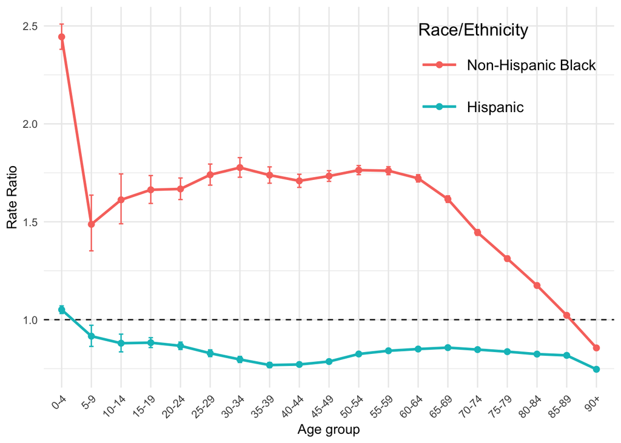

```r
all_cause_age <- all_cause %>%
  group_by(race_eth, age_group) %>%
    summarise(
      deaths = sum(deaths, na.rm=TRUE),
      pop    = sum(population, na.rm=TRUE)
    )
fig4 <- full_join(all_cause_age,hom_age, by = c("race_eth", "age_group")) %>%
  rename(all_cause = deaths.x,
         homicide = deaths.y) %>%
  mutate(deaths=all_cause-homicide,
         rate=deaths/pop*100000) %>%
  set_age_order() %>%
  calc_rr()

plot_rr(fig4,NULL)
```

```r
#do we not have homicide deaths for 0-4?
hom_age %>%
  filter(race_eth == "black",
         age_group == "0-4")
```

```
##   X race_eth age_group      cod deaths population
## 1 1    black       0-4 homicide     91    1104550
```

```r
all_cause_age %>%
   filter(race_eth == "black",
         age_group == "0-4")
```

```
## # A tibble: 1 × 4
## # Groups:   race_eth [1]
##   race_eth age_group deaths      pop
##   <chr>    <chr>      <int>    <dbl>
## 1 black    0-4         8291 3682975.
```

```r
fig4_plot <- plot_rr(fig4,NULL)
ggsave(
  filename = "../Output/fig4UCD.png",
  plot = fig4_plot,
  width = 10,
  height = 6
)
```

Numerically:

```r
table4_by_race <- fig4 %>%
  mutate(rr_ci = sprintf("%.2f (%.2f, %.2f)", rr, rr_lcl, rr_ucl)) %>%
  select(race_eth, age_group, rr_ci) %>%
  arrange(race_eth, age_group) %>%
  group_split(race_eth)

names(table4_by_race) <- unique(fig4$race_eth)

table4_by_race
```

```
## <list_of<
##   tbl_df<
##     race_eth : character
##     age_group: ordered<0b4a0>
##     rr_ci    : character
##   >
## >[2]>
## $black
## # A tibble: 19 × 3
##    race_eth age_group rr_ci
##    <chr>    <ord>     <chr>
##  1 black    0-4       2.44 (2.38, 2.51)
##  2 black    5-9       1.49 (1.35, 1.64)
##  3 black    10-14     1.61 (1.49, 1.74)
##  4 black    15-19     1.66 (1.59, 1.74)
```

[output cut: 39 more lines]

# 7 Motor vehicle

## 7.1 Figure 6: Male by age

Male motor vehicle crash mortality rates, comparing Hispanic, non-Hispanic black, and non-Hispanic white, 5 year age groups with 95% CI, California 2007-2020. We start by following the same methods as before, but run into an issue with missing data due to the CDC query suppression rules. We cleaned a unique dataset with the information needed for this specifically, which we will use.

```r
mvc_age <- read.csv("../CleanData/mvc_UCD_age.csv")
fig6 <- mvc_age %>%
  mutate(rate = deaths/population*100000) %>%
  set_age_order() %>%
  rowwise() %>%
  mutate(ci_log(rate,deaths)) %>%
ungroup()

head(fig6)
```

```
## # A tibble: 6 × 9
##       X race_eth age_group cod   deaths population  rate   lcl   ucl
##   <int> <chr>    <ord>     <chr>  <int>      <dbl> <dbl> <dbl> <dbl>
## 1     1 black    0-4       mvc       34   1104550.  3.08  2.20  4.31
## 2     2 black    10-14     mvc       46   1031841.  4.46  3.34  5.95
## 3     3 black    15-19     mvc      197   1177784. 16.7  14.5  19.2
## 4     4 black    20-24     mvc      409   1224919. 33.4  30.3  36.8
## 5     5 black    25-29     mvc      417   1196638. 34.8  31.7  38.4
## 6     6 black    30-34     mvc      303   1105255. 27.4  24.5  30.7
```

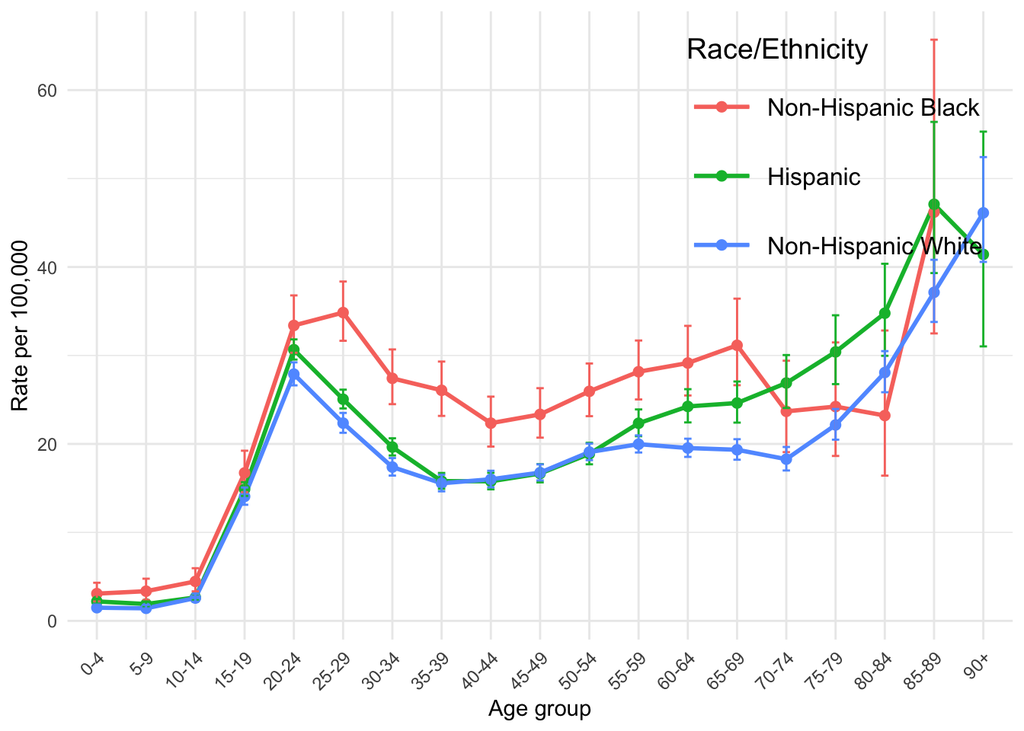

```r
fig6 <- fig6 %>%
  filter(!(race_eth == "black" & age_group == "90+"))

plot_rate(fig6, NULL)
```

```r
fig6_plot <- plot_rate(fig6, NULL)

ggsave(
  filename = "../Output/fig6UCD.png",
  plot = fig6_plot,
  width = 10,
  height = 6
)
```

One thing important to note is that we are missing data for 90+ due to data suppression for Non-Hispanic Blacks, so we will exclude that from the plot and data.

```r
table_6 <- fig6 %>%
  mutate(r_ci = sprintf("%.2f (%.2f, %.2f)", rate, lcl, ucl)) %>%
  select(race_eth, age_group, r_ci) %>%
  arrange(race_eth, age_group) %>%
  group_split(race_eth)

names(table_6) <- unique(fig6$race_eth)

table_6
```

```
## <list_of<
##   tbl_df<
##     race_eth : character
##     age_group: ordered<0b4a0>
##     r_ci     : character
##   >
## >[3]>
## $black
## # A tibble: 18 × 3
##    race_eth age_group r_ci
##    <chr>    <ord>     <chr>
##  1 black    0-4       3.08 (2.20, 4.31)
##  2 black    5-9       3.35 (2.36, 4.77)
##  3 black    10-14     4.46 (3.34, 5.95)
##  4 black    15-19     16.73 (14.55, 19.23)
```

[output cut: 62 more lines]

## 7.2 Figure 7: Male by year (15-24)

Motor vehicle mortality rates, among males 15-24 years of age, comparing Hispanic, non-Hispanic black, and non-Hispanic white, by year with 95% CI, California 2007-2020.

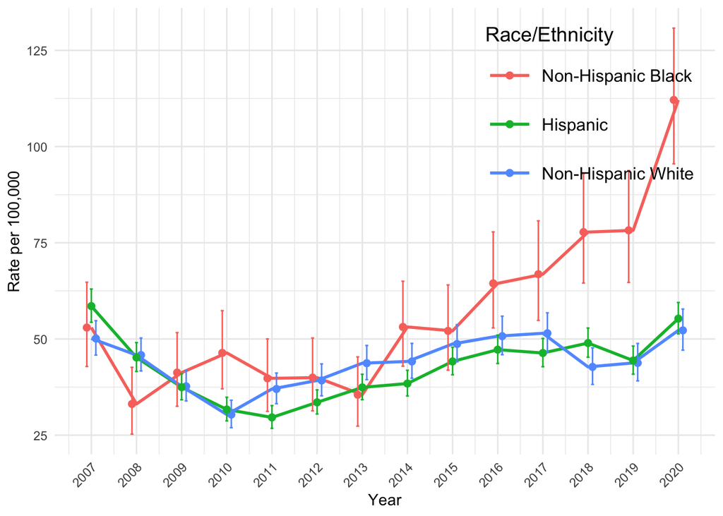

```r
yearly_mvc <- read.csv("../CleanData/mvc_UCD_yearly.csv")

fig7 <- yearly_mvc%>%
  mutate(rate=deaths/population*100000) %>%
  rowwise() %>%
  mutate(ci_exact(deaths,population)) %>%
  ungroup()

plot_yearly(fig7, NULL)
```

```r
fig7_plot <- plot_yearly(fig7, NULL)
ggsave(
  filename = "../Output/fig7UCD.png",
  plot = fig7_plot,
  width = 10,
  height = 6
)
```

```r
table7 <- fig7 %>%
  mutate(r_ci = sprintf("%.2f (%.2f, %.2f)", rate, lcl, ucl)) %>%
  select(race_eth, year, r_ci) %>%
  arrange(race_eth, year) %>%
  group_split(race_eth)

names(table7) <- unique(fig7$race_eth)

table7
```

```
## <list_of<
##   tbl_df<
##     race_eth: character
##     year    : integer
##     r_ci    : character
##   >
## >[3]>
## $black
## # A tibble: 14 × 3
##    race_eth  year r_ci
##    <chr>    <int> <chr>
##  1 black     2007 52.97 (42.85, 64.75)
##  2 black     2008 33.12 (25.27, 42.63)
##  3 black     2009 41.27 (32.51, 51.65)
##  4 black     2010 46.39 (37.05, 57.36)
##  5 black     2011 39.78 (31.18, 50.02)
##  6 black     2012 39.97 (31.33, 50.26)
##  7 black     2013 35.51 (27.35, 45.34)
##  8 black     2014 53.13 (42.93, 65.02)
##  9 black     2015 52.11 (41.90, 64.05)
## 10 black     2016 64.46 (52.88, 77.82)
## 11 black     2017 66.84 (54.83, 80.69)
## 12 black     2018 77.78 (64.54, 92.94)
## 13 black     2019 78.24 (64.71, 93.77)
## 14 black     2020 112.12 (95.52, 130.77)
##
## $white
## # A tibble: 14 × 3
##    race_eth  year r_ci
##    <chr>    <int> <chr>
##  1 hispanic  2007 58.54 (54.35, 62.98)
##  2 hispanic  2008 45.19 (41.56, 49.06)
##  3 hispanic  2009 37.47 (34.21, 40.95)
##  4 hispanic  2010 31.68 (28.72, 34.86)
##  5 hispanic  2011 29.62 (26.77, 32.68)
##  6 hispanic  2012 33.54 (30.51, 36.78)
##  7 hispanic  2013 37.42 (34.23, 40.84)
##  8 hispanic  2014 38.42 (35.19, 41.87)
##  9 hispanic  2015 44.17 (40.70, 47.85)
## 10 hispanic  2016 47.22 (43.63, 51.03)
```

[output cut: 8 more lines]

```
##    <chr>    <int> <chr>
##  1 white     2007 50.14 (45.82, 54.74)
##  2 white     2008 45.82 (41.70, 50.25)
##  3 white     2009 37.70 (33.91, 41.80)
##  4 white     2010 30.36 (26.95, 34.09)
##  5 white     2011 37.01 (33.19, 41.15)
##  6 white     2012 39.22 (35.23, 43.53)
##  7 white     2013 43.71 (39.44, 48.31)
##  8 white     2014 44.16 (39.81, 48.86)
##  9 white     2015 48.71 (44.06, 53.71)
## 10 white     2016 50.73 (45.91, 55.92)
## 11 white     2017 51.48 (46.55, 56.80)
## 12 white     2018 42.74 (38.19, 47.68)
## 13 white     2019 43.78 (39.12, 48.84)
## 14 white     2020 52.24 (47.10, 57.78)
```